# R Notebook

## Question 4

### 4.1: One Model

The goal of propensity score matching is to achieve a balance between the treatment and control groups in variables that may explain selection into treatment. In the Kam and Palmer (2008) paper, they use more than 80 covariates to predict assignment to treatment (attending college). Henderson and Chatfield (2009) demonstrate that after matching students based on these 80+ covariates the balance between treatment and control groups actually gets worse (though improves on several key variables). Both sets of authors agree that there are a number of attributes that explain why some people go to college and others don’t, and Kam and Palmer (2008) list out variables associated with each attribute on page 7. We select four variables from each attribute, plus four demographic variables, for a total of 20 covariates that we believe will predict college attendance. These are listed in the true_covars vector below.

```r
true_covars <- c("student_GPA", "student_PubAff", "student_FamTalk", "student_Knowledge",
                 "student_GovtOpinion", "student_LifeWish", "student_Trust", "student_StrOpinion",
                 "student_Senate", "student_Govern", "student_Hobby", "student_YouthOrg",
                 "parent_HHInc", "parent_Knowledge", "parent_Employ", "parent_EducHH",
                 "student_Gen", "student_Race", "parent_Gen", "parent_Race")


# alternative outcomes
altoutcomevars <- c("student_vote", "student_meeting", "student_other", "student_button",
                 "student_money", "student_communicate", "student_demonstrate", "student_community")

# covariates - exclude outcome vars, any vars from years after treatment
# additional exclude parent_GPHighSchoolPlacebo & parent_HHCollegePlacebo b/c sometimes missing
covars <- colnames(select(d, -interviewid, -college, -student_ppnscal, -all_of(altoutcomevars),
                          -contains("198"), -contains("197"),
                          -parent_GPHighSchoolPlacebo, -parent_HHCollegePlacebo))

# create dataframe without unnecessary covariates
d_base <- select(d, college, student_ppnscal, all_of(true_covars))
```

We estimate the propensity score by regressing assignment to treatment (college) on our 20 covariates. This gives the probability that a student will be in the treatment or control group. The plot below confirms that the propensity scores are higher for people in the treatment group (those that went to college).

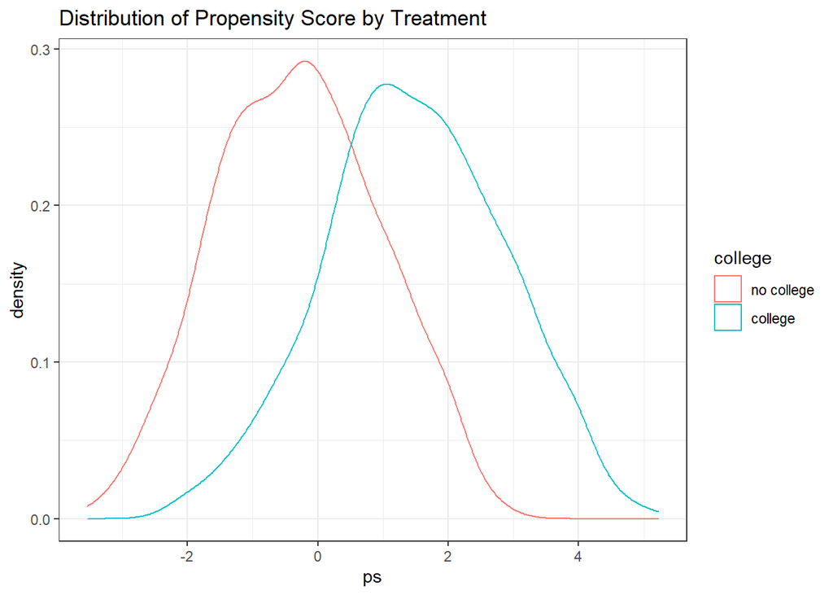

```r
# estimate propensity scores
ps_est <- glm(as.formula(paste('college ~', paste(true_covars, collapse='+'))),
              family = binomial(), data = d)

# look at propensity score across treatment and control groups
d_base %>%
  mutate(ps = predict(ps_est)) %>%
  mutate(college = factor(college, labels = c("no college", "college"))) %>%
  ggplot() +
  geom_density(aes(x = ps, color = college)) +
  theme_bw() +
  labs(title = "Distribution of Propensity Score by Treatment")
```

#### Using MatchIt

Rather than manually matching observations based on their propensity score, we use the MatchIt package to calculate the propensity scores, re-weight the observations based on their propensity scores, and then estimate the average treatment effect on the treated (ATT).

One problem is that there are fewer control units than treated units. We match with replacement so that each of our treated units can be matched to a control unit. A nearest neighbor match with k=1 results in about half our of control units not being matched. Increasing k to 3 means that more of our control units get matched to treatment units (because the threshold for a match is lower). Kam and Palmer also perform a 1 to 3 match, and set their caliper to 0.25 (which we do as well). The concern with increasing k is that units that are not that similar to one another become matched. However, setting the caliper in order to limit the distance between matches combats this.

```r
match_ps_att <- matchit(formula = as.formula(paste('college ~', paste(true_covars, collapse='+'))),
                        data = d, method = "nearest", distance = "glm", link = "logit", estimand = "ATT", replace = TRUE, ratio = 3, caliper = 0.25)
#summary(match_ps_att)

# statistics to report

# proportion of covariates that meet the standardized mean difference <= 0.1
share_bal <- bal.tab(match_ps_att, thresholds = 0.1)$Balance %>%
  transmute(balanced = 1*(M.Threshold == "Balanced, <0.1")) %>%
  unlist() %>%
  mean()

# mean percent improvement in the standardized mean difference
pct_improv <- summary(match_ps_att)$reduction[,1] %>%
  mean()
```

#### Assessing Balance

The plot below shows the distribution of propensity scores by match type. There is a large enough region of common support that all of the treatment units get matched to a control unit. At the top of the propensity score distribution, a few matched units are getting matched many times to different treatment units (shown by the large circles). This is a case of extremity bias that Henderson and Chatfield point out as a problem with the Kam and Palmer paper.

The unmatched control units are the ones with the lowest propensity scores. These units will not be included in the model because, like never-takers, we can never observe their counterfactual of what would have happened if they did go to college. We will loose some statistical power from throwing out these units.

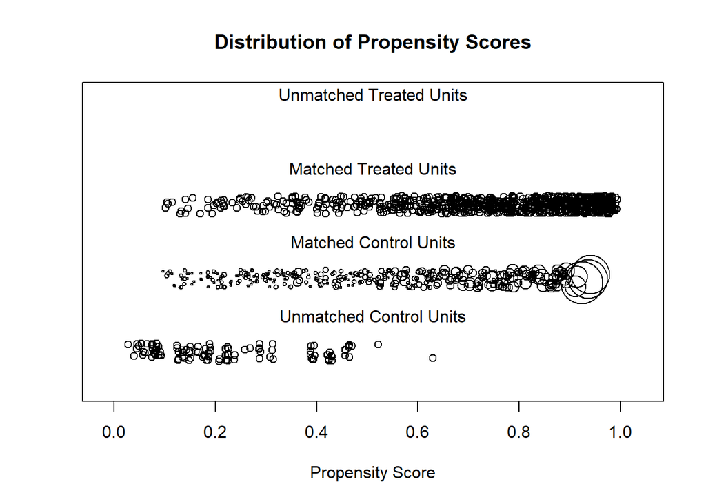

```r
plot(match_ps_att, type = "jitter", interactive = FALSE)
```

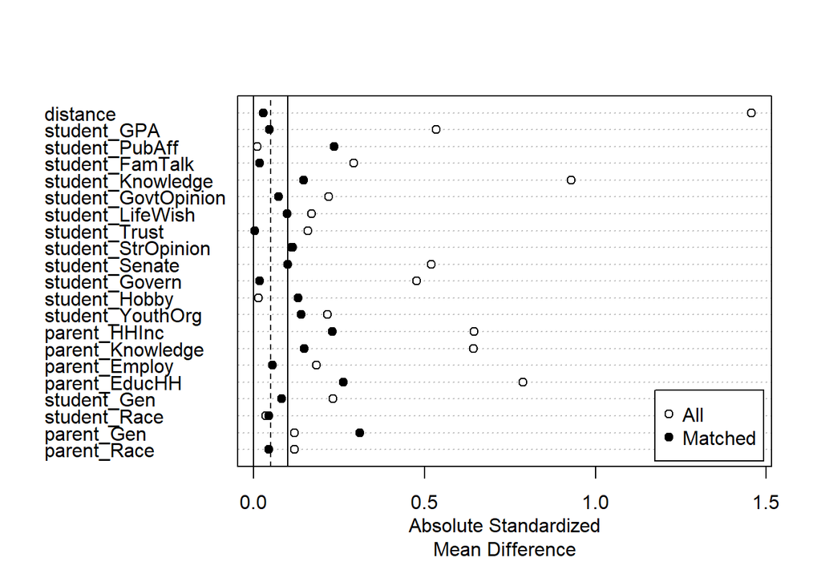

```r
plot(summary(match_ps_att))
```

```r
#bal.tab(match_ps_att, threshold = 0.1)

# covariates that are balanced at the 0.1 threshold
bal_covars <- c("student_GPA", "student_FamTalk", "student_GovtOpinion", "student_LifeWish", "student_Senate", "student_Govern", "parent_Employ", "student_Gen", "student_Race", "parent_Race")
```

The table below shows the percent improvement in balance for each of the covariates. Despite a large increase in the *number* of balanced covariates, matching did not improve the mean difference between control and treatment *overall.* The mean percent improvement is -85.2345 - the negative percent indicates that it got worse. This is mainly due to the substantially worse balance for the student_PubAff variable.

```r
summary(match_ps_att)$reduction
```

```
##                     Std. Mean Diff.  Var. Ratio    eCDF Mean      eCDF Max
## distance                  98.020538    89.18163    95.230271  6.400287e+01
## student_GPA               91.438267   -38.24945    79.546971  8.110024e+01
## student_PubAff         -1982.539683          NA -1982.539683 -1.982540e+03
## student_FamTalk           94.003825    51.59163    70.326621  6.737292e+01
## student_Knowledge         84.219836  -271.88168    81.998199  5.801123e+01
## student_GovtOpinion       67.000218    86.79361    64.621855  5.111457e+01
## student_LifeWish          42.197616    69.72329    42.197616  3.670585e+01
## student_Trust             98.201078   -25.18559    27.272157  1.254781e+01
## student_StrOpinion        -2.480664   -91.69161    -2.480664 -4.952828e-13
## student_Senate            80.794728          NA    80.794728  8.079473e+01
## student_Govern            96.394019          NA    96.394019  9.639402e+01
## student_Hobby           -814.412238 -1081.79244  -389.104220 -3.188172e+02
## student_YouthOrg          35.605769    78.24833   -22.647323 -2.473053e+01
## parent_HHInc              64.340250  -312.66977    59.473461  4.518717e+01
## parent_Knowledge          76.979555 -1001.14193    75.208753  6.553174e+01
## parent_Employ             69.914592          NA    69.914592  6.991459e+01
## parent_EducHH             66.619342   -18.32951    59.576706  4.934845e+01
## student_Gen               64.800701          NA    64.800701  6.480070e+01
## student_Race             -21.481481  -449.42685    44.500846  5.238095e+01
## parent_Gen              -162.225652          NA  -162.225652 -1.622257e+02
## parent_Race               62.684869    33.19530    62.684869  7.210884e+01
##                     Std. Pair Dist.
## distance                         NA
## student_GPA                      NA
## student_PubAff                   NA
## student_FamTalk                  NA
## student_Knowledge                NA
## student_GovtOpinion              NA
## student_LifeWish                 NA
## student_Trust                    NA
## student_StrOpinion               NA
## student_Senate                   NA
## student_Govern                   NA
## student_Hobby                    NA
## student_YouthOrg                 NA
## parent_HHInc                     NA
## parent_Knowledge                 NA
## parent_Employ                    NA
## parent_EducHH                    NA
## student_Gen                      NA
## student_Race                     NA
## parent_Gen                       NA
## parent_Race                      NA
```

#### Estimating the ATT

```r
# estimate ATT
match_ps_att_data <- match.data(match_ps_att)

lm_ps_att <- lm(as.formula(paste('student_ppnscal ~ college +', paste(true_covars, collapse='+'))),
                data = match_ps_att_data, weights = weights)

# store results
lm_ps_att_summ <- summary(lm_ps_att)

# ATT
ATT_ps <- lm_ps_att_summ$coefficients["college", "Estimate"]

# p-value for ATT
ATT_pv <- lm_ps_att_summ$coefficients["college", "Pr(>|t|)"]
```

After matching using propensity scores and k-nearest neighbors, we used the weighted observations estimate the average treatment on the treated (ATT). The ATT is 0.8795716 and is significant at the 1% threshold. This indicates that going to college is associated with participating in nearly one more political activity later in life (for those that go to college). If the selection on observables assumption holds - that conditioning on these 20 covariates assignment to treatment is as good as randomly assigned - then we can interpret this as a causal relationship.

```r
lm_ps_att_summ
```

```
##
## Call:
## lm(formula = as.formula(paste("student_ppnscal ~ college +",
##     paste(true_covars, collapse = "+"))), data = match_ps_att_data,
##     weights = weights)
##
## Weighted Residuals:
##     Min      1Q  Median      3Q     Max
## -4.8544 -1.1474 -0.1738  0.8391  7.7996
##
## Coefficients:
##                      Estimate Std. Error t value Pr(>|t|)
## (Intercept)         -0.492797   0.626612  -0.786  0.43177
## college              0.879572   0.114775   7.663 3.90e-14 ***
## student_GPA          0.008647   0.087784   0.099  0.92155
## student_PubAff      -0.534472   0.211945  -2.522  0.01181 *
## student_FamTalk     -0.167157   0.057418  -2.911  0.00367 **
## student_Knowledge    1.506988   0.324525   4.644 3.83e-06 ***
## student_GovtOpinion -0.040553   0.082427  -0.492  0.62283
## student_LifeWish     0.027395   0.053080   0.516  0.60588
## student_Trust        0.075938   0.053623   1.416  0.15701
## student_StrOpinion  -0.240631   0.054106  -4.447 9.56e-06 ***
## student_Senate      -0.200723   0.138266  -1.452  0.14686
## student_Govern       0.048328   0.235569   0.205  0.83749
## student_Hobby        0.193083   0.061697   3.130  0.00180 **
## student_YouthOrg     0.151933   0.048125   3.157  0.00164 **
## parent_HHInc         0.003696   0.027876   0.133  0.89455
## parent_Knowledge     0.556073   0.270960   2.052  0.04038 *
## parent_Employ        0.539445   0.131136   4.114 4.18e-05 ***
## parent_EducHH        0.126016   0.043752   2.880  0.00405 **
## student_Gen          0.096402   0.113437   0.850  0.39560
## student_Race        -0.490511   0.387717  -1.265  0.20609
## parent_Gen          -0.388873   0.129078  -3.013  0.00265 **
## parent_Race          1.281567   0.396740   3.230  0.00127 **
## ---
## Signif. codes:  0 '***' 0.001 '**' 0.01 '*' 0.05 '.' 0.1 ' ' 1
##
## Residual standard error: 1.703 on 1121 degrees of freedom
## Multiple R-squared:  0.1759, Adjusted R-squared:  0.1604
## F-statistic: 11.39 on 21 and 1121 DF,  p-value: < 2.2e-16
```

### 4.2: Simulation

To investigate how sensitive the ATT estimate is to changes in the covariate specification, we run the propensity score model from above 10,000 times. Each time we randomly sample a subset of the 110 potential covariates from Henderson and Chatfield’s list. The function below:

- randomly samples a subset of covariates
- estimates the propensity score model using MatchIt
- estimates the results ATT
- records the ATT, the share of covariates that are balanced, and the mean percentage improvement in balance

```r
#set simulation parameters
set.seed(1)
iters <- 10000

#generate random selection of covars
n <- sample(1:length(covars), iters, replace = TRUE)
covar_sample <- sapply(n, function(x) sample(covars, size = x))


#store results as a matrix (converting to data frame kept crashing my computer :/)
# first column is att
# second is p-value
# third is balance proportion
# fourth is percent improvement
# fifth is number of covariates

# only run once
if (RUNSIM == TRUE) {

  results <- t(mapply(function(x,y)
      list(
        # grabs lm parameters using hero's code (i love it!! so brilliant)
        summary(lm(as.formula(paste('student_ppnscal ~ college +', paste(x, collapse='+'))),
                    data = match.data(y), weights = weights))$coefficients["college", "Estimate"],


        summary(lm(as.formula(paste('student_ppnscal ~ college +', paste(x, collapse='+'))),
                    data = match.data(y), weights = weights))$coefficients["college", "Pr(>|t|)"],


        # balance proportion
      bal.tab(y, thresholds = 0.1)$Balance %>%
      transmute(balanced = 1*(M.Threshold == "Balanced, <0.1")) %>%
      unlist() %>%
      mean(),


        #percent improvement

      summary(y)$reduction[,1] %>% mean()

      ),


      #data x referred to above

      covar_sample,

      #data y
      lapply(covar_sample, function(z) suppressWarnings(matchit(formula = as.formula(paste('college ~',
                                                                                           paste(z, collapse='+'))),
                           data = d, method = "nearest", distance = "glm", link = "logit",
                           estimand = "ATT", replace = TRUE, ratio = 3)))
  ))

  results <- cbind(results, n)
  colnames(results) <- c("att", "pvalue", "sharebal", "pctimprov", "ncovars")

  # save results
  saveRDS(results, "part4_ps_simulation_results_10000.rds")
}
if (RUNSIM == FALSE){

  results <- readRDS("part4_ps_simulation_results_10000.rds")

}
```

We run the above simulation 10,000 times and save a matrix with the returned results.

The distribution of estimates for the ATT is shown below, with our “true” ATT shown in red. Other than for the models that only had 1, 2 or 3 covariates, the p-value for the ATT was always less than 0.01, indicating that the estimate is significant at the 1% level. The plot shows a slightly right skewed normal distribution of estimated ATTs, with our “true” estimate close to the mean. Our estimates for the ATT are clustered between K&P’s estimate and H&C’s estimates.

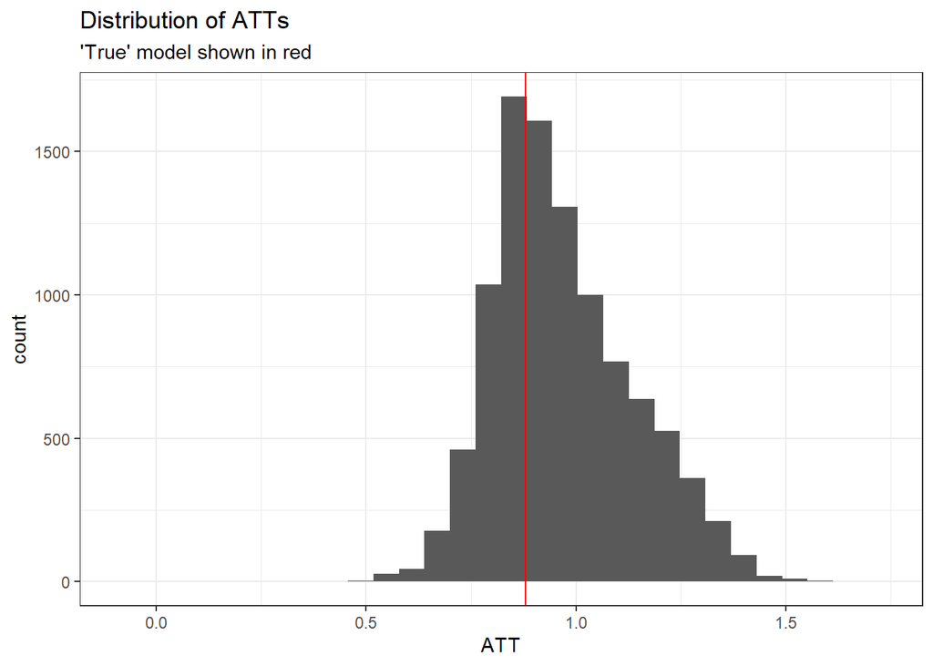

The plot below shows the share of covariates that meet the balance threshold of 0.1 against the estimate for the average treatment on the treated. There is not any clear relationship between the share of balanced covariates and the estimated ATT. There does appear to be some bunching around particular shares of covariates. The plot does not show convergence of ATT like in the K&P paper, but this might be due to our lower number of simulations. Our “true” model sits pretty squarely in the middle of the distribution of the share of balanced covariates.

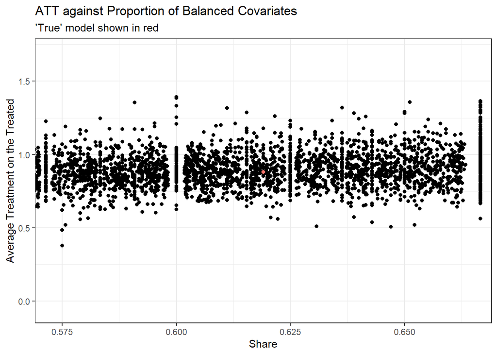

The next plot shows the mean percentage increase in the balance of the covariates after matching (across all the covariates used in that simulation) against the estimate for the ATT. The larger the improvement in the balance of covariates relative to the unmatched units the higher the ATT. Our “true” model had a relatively low degree of mean improvement from matching, mainly driven by one covariate that became very unbalanced after matching.

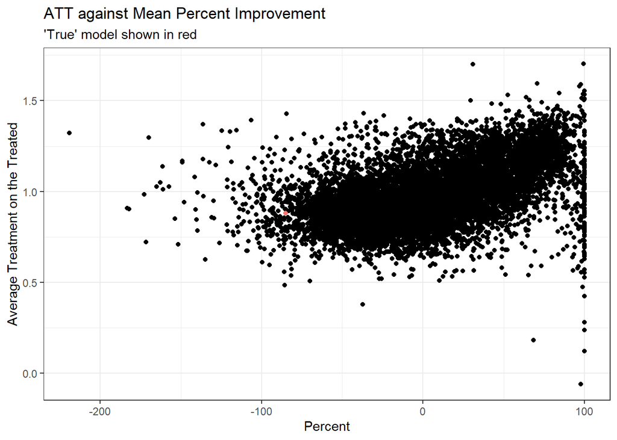

Finally, we show the number of covariates against the ATT. This plot shows convergence toward an ATT of around 0.8 as the number of covariates increases. Interestingly, this is around the same value ATT we got from our “true” model, suggesting that increasing the number of covariates to match on does not improve the model relative to correctly specifying the covariates to match on.

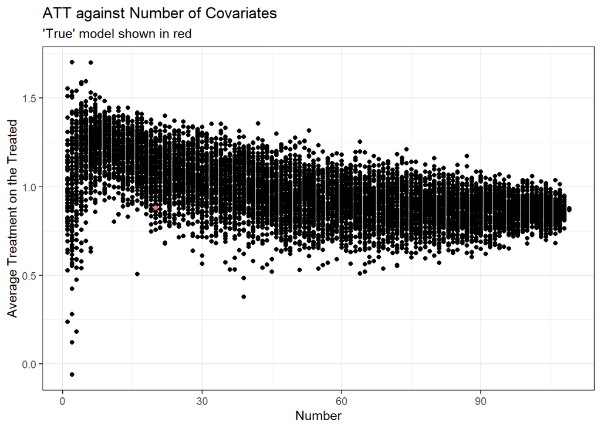

#### Ten Example Simulations

We then select 10 models at random and show the covariate balance plots for each of the 10 models. Because some of the randomly selected models might use a large number of covariates that become difficult to show visually, select only five covariates to display for each model. The five that we select are the ones that appear most in the other 9 models, so that we can asses whether or not the balance improvement changes for covariate x when it is in a model with different other covaraites.

```r
# set seed
set.seed(1)

# function for simulation
ps_match_sim <- function(save_model = FALSE){

  # 1. randomly sample N covariates
  n = sample(1:length(covars),1)
  covar_sample <- sample(covars, size = n)

  # 2. run match it
  match_model <- matchit(formula = as.formula(paste('college ~', paste(covar_sample, collapse='+'))),
                         data = d, method = "nearest", distance = "glm", link = "logit",
                         estimand = "ATT", replace = TRUE, ratio = 3)

  # 3. calculate ATT
  match_data <- match.data(match_model)

  lm_model <- lm(as.formula(paste('student_ppnscal ~ college +', paste(covar_sample, collapse='+'))),
                  data = match_data, weights = weights)

  # 4. store results
  results <- c()

  # ATT
  att <- summary(lm_model)$coefficients["college", "Estimate"]
  results[1] = att

  # p-value for ATT
  att_pv <- summary(lm_model)$coefficients["college", "Pr(>|t|)"]
  results[2] = att_pv

  # number of covariates (stored in n above)
  results[3] = n

  # proportion of covariates that meet the standardized mean difference <= 0.1
  share_bal <- bal.tab(match_model, thresholds = 0.1)$Balance %>%
    transmute(balanced = 1*(M.Threshold == "Balanced, <0.1")) %>%
    unlist() %>%
    mean()
  results[4] = share_bal

  # mean percent improvement in the standardized mean difference
  pct_improv <- summary(match_model)$reduction[,1] %>%
    mean()
  results[5] = pct_improv

  results <- round(results, digits = 4)

  # if on, save all model attributes and list of covars
  if (save_model == TRUE){

    results = list(results,
                   match_model,
                   covar_sample)
  }

  return(results)
}
```

```r
# run 10 times
sim10 <- replicate(10, ps_match_sim(save_model = T), simplify = FALSE)
```

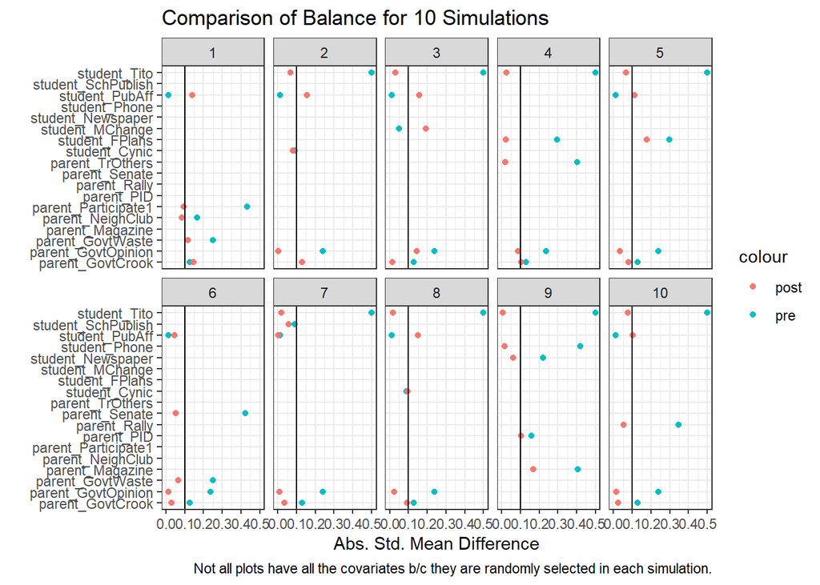

```r
# function to return df with covariate, pre- and post-absolute standardized mean differenace
balance_plot <- function(i = 1){

  # number of covars + 1
  k <- length(sim10[[i]][[3]])+1

  p_df <- data.frame(vars = sim10[[i]][[3]],
                     dif_pre = unname(abs(summary(sim10[[i]][[2]])$sum.all[2:k,3])),
                     dif_post = unname(abs(summary(sim10[[i]][[2]])$sum.matched[2:k,3])),
                     sim = i,
                     ncov = k-1)

  # take a sample of min(10,n) covars for plot
  #s_size <- min(10, nrow(p_df))
  #p_df <- sample_n(p_df, s_size)

  return(p_df)
}

# run for all 10 models
df10 <- lapply(1:10, balance_plot) %>% bind_rows()

# limit to 5 covariates per model based on overlap with other models
df10 <- df10 %>%
  group_by(vars) %>%
  mutate(freq = n()) %>%
  group_by(sim) %>%
  arrange(-freq, .by_gruop = TRUE) %>%
  slice(1:5)


# show balance plots for the 10 models
ggplot(df10) +
  geom_point(aes(x = dif_pre, y = vars, color = "pre")) +
  geom_point(aes(x = dif_post, y = vars, color = "post")) +
  geom_vline(xintercept = 0.1) +
  xlab("Abs. Std. Mean Difference") +
  ylab("") +
  facet_wrap("sim", nrow = 2) +
  theme_bw() +
  labs(title = "Comparison of Balance for 10 Simulations",
       caption = "Not all plots have all the covariates b/c they are randomly selected in each simulation.")
```

### 4.3: Questions

**1. How many simulations resulted in models with a higher proportion of balanced covariates? Do you have any concerns about this?** Our “true” model sat squarely in the middle of the simulations in terms of the share of balanced covariates. Given that the ATT did not change much with the share of balanced covariates, we are not concerned that our true model was more balanced than only half of the simulation models. The range of the share of balanced covariates was also not that large - the least balanced were around 56% and the most around 68%.

**3. Do your 10 randomly chosen covariate balance plots produce similar numbers on the same covariates? Is it a concern if they do not?** Most of the covariate balance plots show similar numbers on the same covariates *post* matching. In general, covariates that were imbalanced before matching and balanced after matching display this trend regardless of the model they’re in. This is encouraging because it implies that the treatment and control groups have similar characteristics across the different models post matching. If they did not have similar balance plots across models it would suggest that observations were being matched differently depending on the combination of covariates that are matched on. If an observation can get matched differently across models then it is like saying there are multiple counterfactuals for one observation and we would probably have an imprecisely estimated ATT.